# PA1

Matteo

Friday, January 09, 2015

## Loading and preprocessing the data

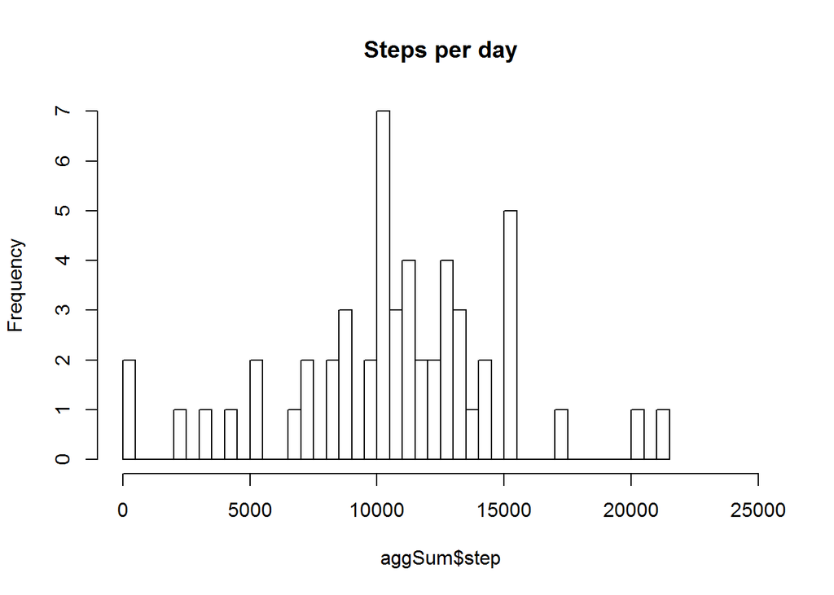

```r
setwd("C:\\Users\\Automation\\Documents\\R\\RepData_PeerAssessment1")
unzip("activity.zip")
dataStep <- read.csv("activity.csv")

aggSum <- aggregate(steps ~ date, data = dataStep, FUN = sum)
hist(aggSum$step, 53, main = "Steps per day", xlim = c(0,25000))
```

```r
mean(aggSum$steps)
```

```
## [1] 10766.19
```

## What is mean total number of steps taken per day?

```r
meanStep <- mean(aggSum$step)
medianStep <- median(aggSum$step)

meanStep
```

```
## [1] 10766.19
```

```r
medianStep
```

```
## [1] 10765
```

## What is the average daily activity pattern?

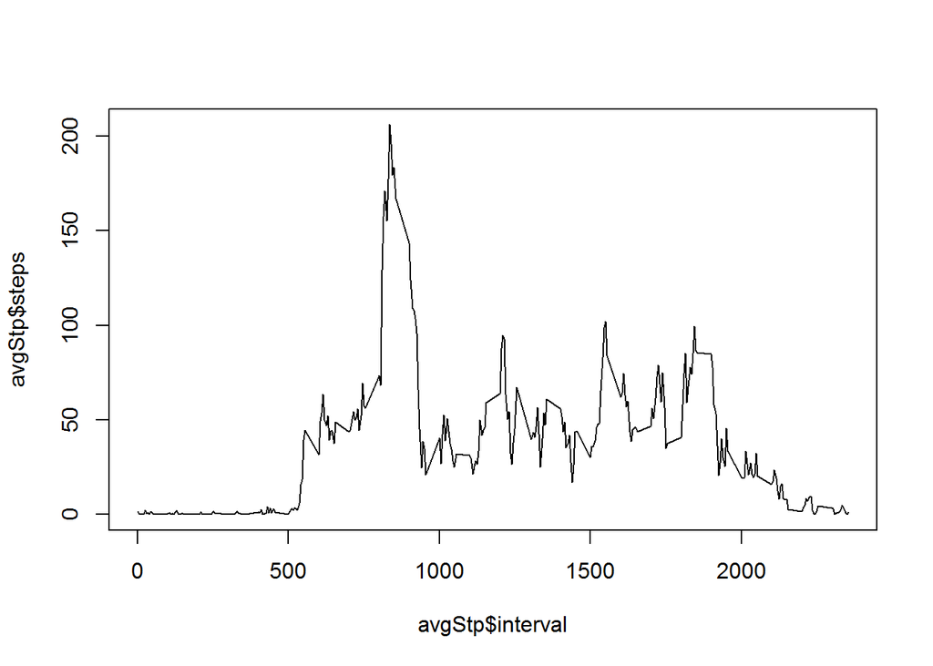

```r
avgStp <- aggregate(steps ~ interval, data = dataStep, FUN = mean)
plot(avgStp$interval, avgStp$steps, type = "l")
```

```r
maxStp <- avgStp[max(avgStp$steps),1]
maxStp
```

```
## [1] 1705
```

## Imputing missing values

1. Calculate and report the total number of missing values in the dataset (i.e. the total number of rows with NAs)

```r
sum(is.na(dataStep))
```

```
## [1] 2304
```

2. Devise a strategy for filling in all of the missing values in the dataset. The strategy does not need to be sophisticated. For example, you could use the mean/median for that day, or the mean for that 5-minute interval, etc.

I decided to replace the missing values with the average values of the interval missing. This strategy stabilizes the mean and makes the median also closer to the mean.

3. Create a new dataset that is equal to the original dataset but with the missing data filled in.

```r
dataNoNa <- dataStep
for (i in 1:dim(dataNoNa[1])) {
        if (is.na(dataNoNa[i,1] == TRUE)) {
                dataNoNa[i,1] <- avgStp[avgStp$interval == dataNoNa[i,3],2]
                }
}
avgNoNa <- aggregate(steps ~ interval, data = dataNoNa, FUN = mean)
```

4. Make a histogram of the total number of steps taken each day and Calculate and report the mean and median total number of steps taken per day. Do these values differ from the estimates from the first part of the assignment? What is the impact of imputing missing data on the estimates of the total daily number of steps?

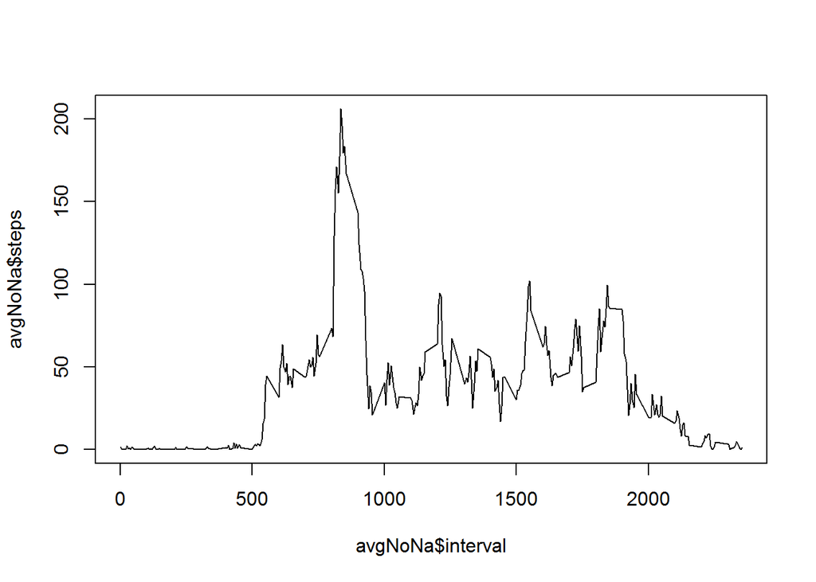

```r
plot(avgNoNa$interval, avgNoNa$steps, type = "l")
```

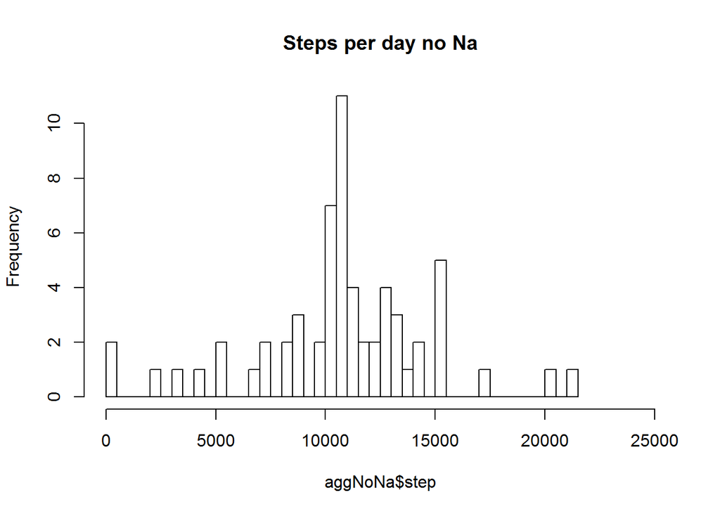

```r
aggNoNa <- aggregate(steps ~ date, data = dataNoNa, FUN = sum)
hist(aggNoNa$step, 53, main = "Steps per day no Na", xlim = c(0,25000))
```

```r
stepsDayNoNa <- aggregate(steps ~ date, data = dataNoNa, FUN = sum)
meanNoNa <- mean(stepsDayNoNa$step)
medianNoNa <- median(stepsDayNoNa$step)
meanNoNa
```

```
## [1] 10766.19
```

```r
medianNoNa
```

```
## [1] 10766.19
```

Since I decided to use the average amount of step per interval to substitue NA values, the average doesn’t change due to the very definition of mean. The median however increases slightly to match the average.

## Are there differences in activity patterns between weekdays and weekends?

```r
library(scales)
```

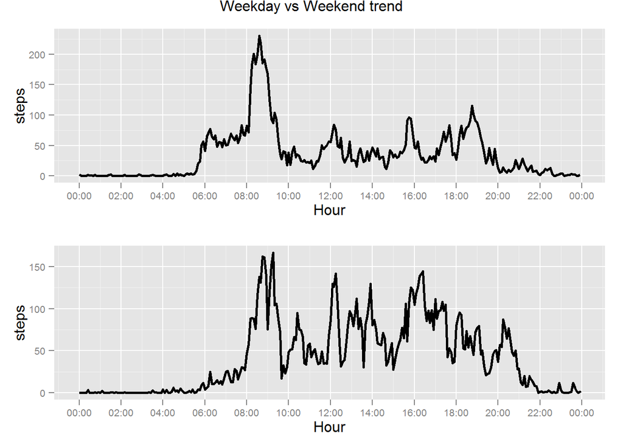

```r
library(ggplot2)
library(grid)
library(gridExtra)
dataNoNa$weekday <- as.character(weekdays(as.Date(dataNoNa$date)))
dataNoNa$weekday[dataNoNa$weekday == "Monday"] <- "Weekday"
dataNoNa$weekday[dataNoNa$weekday == "Tuesday"] <- "Weekday"
dataNoNa$weekday[dataNoNa$weekday == "Wednesday"] <- "Weekday"
dataNoNa$weekday[dataNoNa$weekday == "Thursday"] <- "Weekday"
dataNoNa$weekday[dataNoNa$weekday == "Friday"] <- "Weekday"
dataNoNa$weekday[dataNoNa$weekday == "Saturday"] <- "Weekend"
dataNoNa$weekday[dataNoNa$weekday == "Sunday"] <- "Weekend"
dataNoNa$weekday <- as.factor(dataNoNa$weekday)
WeekAvg <- aggregate(steps ~ interval + weekday, data = dataNoNa, mean)

time <- cbind(WeekAvg$interval%/%100, WeekAvg$interval-(WeekAvg$interval%/%100)*100)
time <- as.data.frame(time)
time2 <- ISOdatetime(2015, 01, 01, time$V1, time$V2, 00)
WeekAvg$time2 <- time2

wkd<-WeekAvg[1:288,]
wke<-WeekAvg[288:576,]
pwe <- ggplot(wke, aes(x=time2, y = steps)) + geom_line (size = 1) + scale_x_datetime(labels = date_format("%H:%M"),breaks = "2 hour") + theme (axis.text=element_text(size=8))+ xlab("Hour")
pwd <- ggplot(wkd, aes(x=time2, y = steps)) + geom_line (size = 1) + scale_x_datetime(labels = date_format("%H:%M"),breaks = "2 hour") + theme (axis.text=element_text(size=8))+ xlab("Hour")
grid.arrange(pwd, pwe, ncol = 1, main = "Weekday vs Weekend trend")
```